# Random Forest Analysis of the UCI Weight Lifting Exercises Dataset

Kenneth Moats

## Introduction

Using devices such as Jawbone Up, Nike FuelBand, and Fitbit, it is now possible to collect a large amount of data about personal activity relatively inexpensively. These types of devices are part of the quantified self movement – a group of enthusiasts who take measurements about themselves regularly to improve their health, to find patterns in their behavior, or because they are tech geeks. One thing that people regularly do is quantify how much of a particular activity they do, but they rarely quantify how well they do it.

The data in this project can be found at http://groupware.les.inf.puc-rio.br/har. Six participants were asked to perform dumbbell biceps curls correctly and incorrectly in 5 different ways:

```
A: exactly according to the specification
B: throwing the elbows to the front
C: lifting the dumbbell only halfway
D: lowering the dumbbell only halfway
E: throwing the hips to the front
```

This is the “classe” variable in the training set. The goal of this project is to predict the manner in which they did the exercise, based on data from accelerometers on the belt, forearm, arm, and dumbell. Any of these other variables may be used as predictors.

## Load Libraries

```r
library(caret)

# enable multi-core processing
library(doParallel)
#cl <- makeCluster(detectCores())
registerDoParallel()
set.seed(12345)
```

## Load Training and Testing Data

```r
downloadfile <- function(fileurl, filename){
        if(!file.exists(filename)) {
                download.file(fileurl, destfile = filename, method = "curl")
                date_downloaded <- date()
                }
        read.csv(filename)
        }

traindata <- downloadfile("https://d396qusza40orc.cloudfront.net/predmachlearn/pml-training.csv", "trainingdata.csv")
testdata <- downloadfile("https://d396qusza40orc.cloudfront.net/predmachlearn/pml-testing.csv", "testdata.csv")
```

## Exploratory Data Analysis

First we examine the training data.

```r
str(traindata)
```

```
## 'data.frame':    19622 obs. of  160 variables:
##  $ X                       : int  1 2 3 4 5 6 7 8 9 10 ...
##  $ user_name               : Factor w/ 6 levels "adelmo","carlitos",..: 2 2 2 2 2 2 2 2 2 2 ...
##  $ raw_timestamp_part_1    : int  1323084231 1323084231 1323084231 1323084232 1323084232 1323084232 1323084232 1323084232 1323084232 1323084232 ...
##  $ raw_timestamp_part_2    : int  788290 808298 820366 120339 196328 304277 368296 440390 484323 484434 ...
##  $ cvtd_timestamp          : Factor w/ 20 levels "02/12/2011 13:32",..: 9 9 9 9 9 9 9 9 9 9 ...
##  $ new_window              : Factor w/ 2 levels "no","yes": 1 1 1 1 1 1 1 1 1 1 ...
##  $ num_window              : int  11 11 11 12 12 12 12 12 12 12 ...
##  $ roll_belt               : num  1.41 1.41 1.42 1.48 1.48 1.45 1.42 1.42 1.43 1.45 ...
##  $ pitch_belt              : num  8.07 8.07 8.07 8.05 8.07 8.06 8.09 8.13 8.16 8.17 ...
##  $ yaw_belt                : num  -94.4 -94.4 -94.4 -94.4 -94.4 -94.4 -94.4 -94.4 -94.4 -94.4 ...
##  $ total_accel_belt        : int  3 3 3 3 3 3 3 3 3 3 ...
##  $ kurtosis_roll_belt      : Factor w/ 397 levels "","-0.016850",..: 1 1 1 1 1 1 1 1 1 1 ...
##  $ kurtosis_picth_belt     : Factor w/ 317 levels "","-0.021887",..: 1 1 1 1 1 1 1 1 1 1 ...
##  $ kurtosis_yaw_belt       : Factor w/ 2 levels "","#DIV/0!": 1 1 1 1 1 1 1 1 1 1 ...
```

[output cut: 86 more lines]

We see that there are 160 variables in the training data set. To reduce the number of predictors, we determine which variables contain missing values and determine the fraction of missing values for those variables.

```r
countnas <- function(data) {
        sum(is.na(data))
        }

numbernas <- function(data) {
        apply(data, MARGIN = 2, countnas)
        }

fractionnas <- function(data) {
        numbernas(data)/nrow(data)
        }

print(fractionnas(traindata)[which(fractionnas(traindata) > 0)])
```

```
##            max_roll_belt           max_picth_belt            min_roll_belt
##                0.9793089                0.9793089                0.9793089
##           min_pitch_belt      amplitude_roll_belt     amplitude_pitch_belt
##                0.9793089                0.9793089                0.9793089
##     var_total_accel_belt            avg_roll_belt         stddev_roll_belt
##                0.9793089                0.9793089                0.9793089
##            var_roll_belt           avg_pitch_belt        stddev_pitch_belt
##                0.9793089                0.9793089                0.9793089
##           var_pitch_belt             avg_yaw_belt          stddev_yaw_belt
##                0.9793089                0.9793089                0.9793089
##             var_yaw_belt            var_accel_arm             avg_roll_arm
##                0.9793089                0.9793089                0.9793089
##          stddev_roll_arm             var_roll_arm            avg_pitch_arm
##                0.9793089                0.9793089                0.9793089
##         stddev_pitch_arm            var_pitch_arm              avg_yaw_arm
##                0.9793089                0.9793089                0.9793089
##           stddev_yaw_arm              var_yaw_arm             max_roll_arm
##                0.9793089                0.9793089                0.9793089
##            max_picth_arm              max_yaw_arm             min_roll_arm
##                0.9793089                0.9793089                0.9793089
##            min_pitch_arm              min_yaw_arm       amplitude_roll_arm
##                0.9793089                0.9793089                0.9793089
##      amplitude_pitch_arm        amplitude_yaw_arm        max_roll_dumbbell
##                0.9793089                0.9793089                0.9793089
##       max_picth_dumbbell        min_roll_dumbbell       min_pitch_dumbbell
##                0.9793089                0.9793089                0.9793089
##  amplitude_roll_dumbbell amplitude_pitch_dumbbell       var_accel_dumbbell
##                0.9793089                0.9793089                0.9793089
##        avg_roll_dumbbell     stddev_roll_dumbbell        var_roll_dumbbell
##                0.9793089                0.9793089                0.9793089
##       avg_pitch_dumbbell    stddev_pitch_dumbbell       var_pitch_dumbbell
##                0.9793089                0.9793089                0.9793089
##         avg_yaw_dumbbell      stddev_yaw_dumbbell         var_yaw_dumbbell
##                0.9793089                0.9793089                0.9793089
##         max_roll_forearm        max_picth_forearm         min_roll_forearm
##                0.9793089                0.9793089                0.9793089
##        min_pitch_forearm   amplitude_roll_forearm  amplitude_pitch_forearm
##                0.9793089                0.9793089                0.9793089
##        var_accel_forearm         avg_roll_forearm      stddev_roll_forearm
##                0.9793089                0.9793089                0.9793089
##         var_roll_forearm        avg_pitch_forearm     stddev_pitch_forearm
##                0.9793089                0.9793089                0.9793089
##        var_pitch_forearm          avg_yaw_forearm       stddev_yaw_forearm
##                0.9793089                0.9793089                0.9793089
##          var_yaw_forearm
##                0.9793089
```

## Data Cleaning

Based on the above exploratory data analysis, there are several variables that contain approximately 97.9% missing values. The following code removes these variables from both the training and testing data sets. We also only keep variables related to the belt, forearm, arm and dumbell motion, that appear in both training and testing data sets, as we are interested in how these variables can be used to predict the classe variable (variables such as “user_name”, “raw_timestamp_part1”, etc…, are unlikely to affect the type of exercise).

```r
cleandata <- function(data){
        data <- data[ , -which(fractionnas(data) > 0.97)]
        data[, grep("classe|belt|arm|dumbbell",names(data))]
        }

traindata <- cleandata(traindata)
testdata <- cleandata(testdata)

traindata <- traindata[, which((names(traindata) %in% names(testdata)) | names(traindata)=="classe")]
```

## Create Cross Validation Data Set

We use 60% of the training data set for training and the other 40% for cross validation

```r
inTrain <- createDataPartition(y = traindata$classe, p = 0.6, list = FALSE)
validationdata <- traindata[-inTrain, ]
traindata <- traindata[inTrain, ]
```

We now check the dimensions of the training, validation and testing data sets.

```r
dim(traindata)
```

```
## [1] 11776    53
```

```r
dim(validationdata)
```

```
## [1] 7846   53
```

```r
dim(testdata)
```

```
## [1] 20 52
```

## Building a Model using the Training Data Set

We choose to train a model using a random forest for several reasons. Random forests are well suited to handle a large number of predictors, especially when the interactions between them are unknown. Random forests also have a high accuracy rate and a built-in cross-validation component that allows an estimate of the out-of-sample error rate. The model is built using the 52 predictors in the training set. 5-fold cross validation is used as the train control method.

```r
rfFit <- train(classe ~ ., traindata, method = "rf", trControl=trainControl(method = 'cv', number = 5), allowParallel = TRUE)

print(rfFit)
```

```
## Random Forest
##
## 11776 samples
##    52 predictor
##     5 classes: 'A', 'B', 'C', 'D', 'E'
##
## No pre-processing
## Resampling: Cross-Validated (5 fold)
##
## Summary of sample sizes: 9420, 9421, 9420, 9420, 9423
##
## Resampling results across tuning parameters:
##
##   mtry  Accuracy   Kappa      Accuracy SD  Kappa SD
##    2    0.9875174  0.9842085  0.002002016  0.002534003
##   27    0.9887918  0.9858207  0.002674417  0.003385408
##   52    0.9853106  0.9814156  0.004392719  0.005561658
##
## Accuracy was used to select the optimal model using  the largest value.
## The final value used for the model was mtry = 27.
```

```r
print(rfFit$finalModel)
```

```
##
## Call:
##  randomForest(x = x, y = y, mtry = param$mtry, allowParallel = TRUE)
##                Type of random forest: classification
##                      Number of trees: 500
## No. of variables tried at each split: 27
##
##         OOB estimate of  error rate: 0.85%
## Confusion matrix:
##      A    B    C    D    E class.error
## A 3340    6    1    0    1 0.002389486
## B   19 2251    8    0    1 0.012286090
## C    0    6 2036   12    0 0.008763389
## D    0    0   28 1899    3 0.016062176
## E    0    1    5    9 2150 0.006928406
```

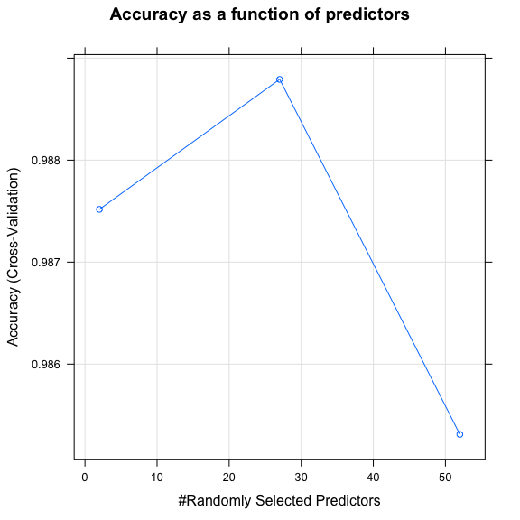

```r
plot(rfFit, main = "Accuracy as a function of predictors")
```

The importance of the predictors in the model are shown below:

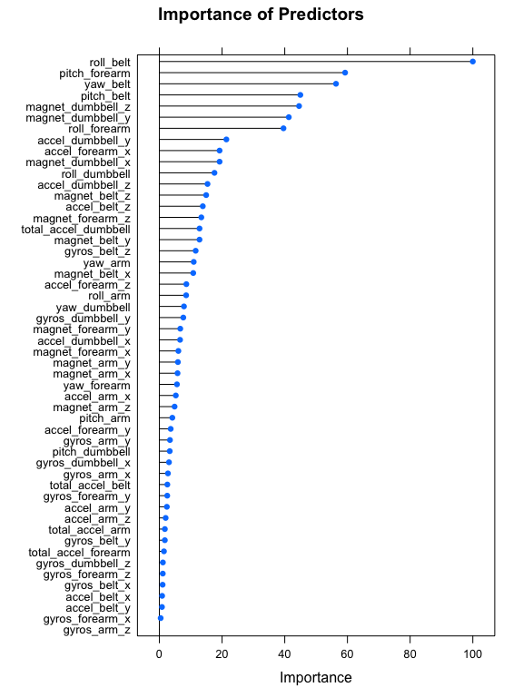

```r
plot(varImp(rfFit), main = "Importance of Predictors")
```

## Assessing the Accuracy of the Model using the Validation Data Set

We now assess the accuracy of our model using the validation data set.

```r
rfPredict <- predict(rfFit, validationdata)
confusionMatrix(rfPredict, validationdata$classe)
```

```
## Confusion Matrix and Statistics
##
##           Reference
## Prediction    A    B    C    D    E
##          A 2229   11    0    0    0
##          B    3 1502    5    0    2
##          C    0    5 1358   19    3
##          D    0    0    5 1265    5
##          E    0    0    0    2 1432
##
## Overall Statistics
##
##                Accuracy : 0.9924
##                  95% CI : (0.9902, 0.9942)
##     No Information Rate : 0.2845
##     P-Value [Acc > NIR] : < 2.2e-16
##
##                   Kappa : 0.9903
##  Mcnemar's Test P-Value : NA
##
## Statistics by Class:
##
##                      Class: A Class: B Class: C Class: D Class: E
## Sensitivity            0.9987   0.9895   0.9927   0.9837   0.9931
## Specificity            0.9980   0.9984   0.9958   0.9985   0.9997
## Pos Pred Value         0.9951   0.9934   0.9805   0.9922   0.9986
## Neg Pred Value         0.9995   0.9975   0.9985   0.9968   0.9984
## Prevalence             0.2845   0.1935   0.1744   0.1639   0.1838
## Detection Rate         0.2841   0.1914   0.1731   0.1612   0.1825
## Detection Prevalence   0.2855   0.1927   0.1765   0.1625   0.1828
## Balanced Accuracy      0.9983   0.9939   0.9943   0.9911   0.9964
```

The accuracy of the model is 99.24%, so we expect that this model predicts the outcome in the classe variable quite well.

## Predicting the Outcome using the Testing Data Set

We now predict the outcomes of the 20 cases from the testing data set. These outcomes are printed below and each outcome is written to an output file.

```r
predictions <- predict(rfFit, testdata)
print(predictions)
```

```
##  [1] B A B A A E D B A A B C B A E E A B B B
## Levels: A B C D E
```

```r
# Generate output file for each of the 20 cases
pml_write_files = function(x){
        n = length(x)
        for(i in 1:n){
                filename = paste0("problem_id_",i,".txt")
                write.table(x[i],file=filename,quote=FALSE,row.names=FALSE,col.names=FALSE)
        }
}

setwd("submission")
pml_write_files(predictions)
```